# Project Foundations for Data Science: FoodHub Data Analysis

### Context

The number of restaurants in New York is increasing day by day. Lots of students and busy professionals rely on those restaurants due to their hectic lifestyles. Online food delivery service is a great option for them. It provides them with good food from their favorite restaurants. A food aggregator company FoodHub offers access to multiple restaurants through a single smartphone app.

The app allows the restaurants to receive a direct online order from a customer. The app assigns a delivery person from the company to pick up the order after it is confirmed by the restaurant. The delivery person then uses the map to reach the restaurant and waits for the food package. Once the food package is handed over to the delivery person, he/she confirms the pick-up in the app and travels to the customer's location to deliver the food. The delivery person confirms the drop-off in the app after delivering the food package to the customer. The customer can rate the order in the app. The food aggregator earns money by collecting a fixed margin of the delivery order from the restaurants.

### Objective

The food aggregator company has stored the data of the different orders made by the registered customers in their online portal. They want to analyze the data to get a fair idea about the demand of different restaurants which will help them in enhancing their customer experience. Suppose you are hired as a Data Scientist in this company and the Data Science team has shared some of the key questions that need to be answered. Perform the data analysis to find answers to these questions that will help the company to improve the business.

### Data Description

The data contains the different data related to a food order. The detailed data dictionary is given below.

### Data Dictionary

- order_id: Unique ID of the order
- customer_id: ID of the customer who ordered the food
- restaurant_name: Name of the restaurant
- cuisine_type: Cuisine ordered by the customer
- cost: Cost of the order
- day_of_the_week: Indicates whether the order is placed on a weekday or weekend (The weekday is from Monday to Friday and the weekend is Saturday and Sunday)
- rating: Rating given by the customer out of 5
- food_preparation_time: Time (in minutes) taken by the restaurant to prepare the food. This is calculated by taking the difference between the timestamps of the restaurant's order confirmation and the delivery person's pick-up confirmation.
- delivery_time: Time (in minutes) taken by the delivery person to deliver the food package. This is calculated by taking the difference between the timestamps of the delivery person's pick-up confirmation and drop-off information

### Let us start by importing the required libraries

```python
# import libraries for data manipulation
import numpy as np
import pandas as pd

# import libraries for data visualization
import matplotlib.pyplot as plt
import seaborn as sns

from google.colab import drive
drive.mount('/content/drive')
```

### Understanding the structure of the data

```python
# read the data
df = pd.read_csv('/content/drive/MyDrive/datasets/foodhub_order.csv')
# returns the first 5 rows
df.head()
```

|  | order_id | customer_id | restaurant_name | cuisine_type | cost_of_the_order | day_of_the_week | rating | food_preparation_time | delivery_time |
| --- | --- | --- | --- | --- | --- | --- | --- | --- | --- |
| 0 | 1477147 | 337525 | Hangawi | Korean | 30.75 | Weekend | Not given | 25 | 20 |
| 1 | 1477685 | 358141 | Blue Ribbon Sushi Izakaya | Japanese | 12.08 | Weekend | Not given | 25 | 23 |
| 2 | 1477070 | 66393 | Cafe Habana | Mexican | 12.23 | Weekday | 5 | 23 | 28 |
| 3 | 1477334 | 106968 | Blue Ribbon Fried Chicken | American | 29.20 | Weekend | 3 | 25 | 15 |
| 4 | 1478249 | 76942 | Dirty Bird to Go | American | 11.59 | Weekday | 4 | 25 | 24 |

#### Observations:

The DataFrame has 9 columns as mentioned in the Data Dictionary. Data in each row corresponds to the order placed by a customer.

### **Question 1:** How many rows and columns are present in the data? [0.5 mark]

```python
df.shape
```

```
(1898, 9)
```

#### Observations: There are 1898 rows and 9 columns.

### **Question 2:** What are the datatypes of the different columns in the dataset? (The info() function can be used) [0.5 mark]

```python
df.info()
```

```
<class 'pandas.core.frame.DataFrame'>
RangeIndex: 1898 entries, 0 to 1897
Data columns (total 9 columns):
 #   Column                 Non-Null Count  Dtype
---  ------                 --------------  -----
 0   order_id               1898 non-null   int64
 1   customer_id            1898 non-null   int64
 2   restaurant_name        1898 non-null   object
 3   cuisine_type           1898 non-null   object
 4   cost_of_the_order      1898 non-null   float64
 5   day_of_the_week        1898 non-null   object
 6   rating                 1898 non-null   object
 7   food_preparation_time  1898 non-null   int64
 8   delivery_time          1898 non-null   int64
dtypes: float64(1), int64(4), object(4)
memory usage: 133.6+ KB
```

#### Observations: The dataset containts integers, floats, and objects.

### **Question 3:** Are there any missing values in the data? If yes, treat them using an appropriate method. [1 mark]

```python
#adding all isnull values per column
df.isna().sum()
```

```
order_id                 0
customer_id              0
restaurant_name          0
cuisine_type             0
cost_of_the_order        0
day_of_the_week          0
rating                   0
food_preparation_time    0
delivery_time            0
dtype: int64
```

#### Observations: There are zero missing values.

### **Question 4:** Check the statistical summary of the data. What is the minimum, average, and maximum time it takes for food to be prepared once an order is placed? [2 marks]

```python
#using .describe to get stat summary
df.describe()
```

|  | order_id | customer_id | cost_of_the_order | food_preparation_time | delivery_time |
| --- | --- | --- | --- | --- | --- |
| count | 1.898000e+03 | 1898.000000 | 1898.000000 | 1898.000000 | 1898.000000 |
| mean | 1.477496e+06 | 171168.478398 | 16.498851 | 27.371970 | 24.161749 |
| std | 5.480497e+02 | 113698.139743 | 7.483812 | 4.632481 | 4.972637 |
| min | 1.476547e+06 | 1311.000000 | 4.470000 | 20.000000 | 15.000000 |
| 25% | 1.477021e+06 | 77787.750000 | 12.080000 | 23.000000 | 20.000000 |
| 50% | 1.477496e+06 | 128600.000000 | 14.140000 | 27.000000 | 25.000000 |
| 75% | 1.477970e+06 | 270525.000000 | 22.297500 | 31.000000 | 28.000000 |
| max | 1.478444e+06 | 405334.000000 | 35.410000 | 35.000000 | 33.000000 |

#### Observations: min : 20 mins, max: 35 mins, average: 27.37 mins

### **Question 5:** How many orders are not rated? [1 mark]

```python
#filtering value_counts to 'Not given'
df['rating'].value_counts()['Not given']
```

```
736
```

#### Observations: There 736 orders that are unrated.

### Exploratory Data Analysis (EDA)

### **Question 6:** Explore all the variables and provide observations on their distributions. (Generally, histograms, boxplots, countplots, etc. are used for univariate exploration.) [9 marks]

### Cost

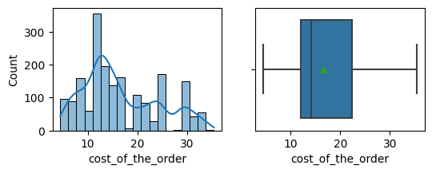

```python
#using a subplot with dimensions of 1 row 2 columns to keep graphs horizontally aligned.
fig, ax =plt.subplots(1,2,figsize=(6, 2))
#creating and setting the hisplot to the first position in the sublot
sns.histplot(data=df,x = 'cost_of_the_order', kde=True, ax=ax[0])
#creating and setting the boxplot to the second position in the sublot,set showmeans = True to see average on boxplot
sns.boxplot(data=df,x = 'cost_of_the_order',showmeans=True,ax=ax[1])
fig.show()
```

### Prep Time

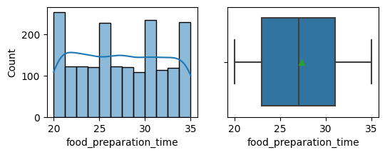

```python
#using a subplot with dimensions of 1 row 2 columns to keep graphs horizontally aligned.
#set showmeans = True to see average on boxplot.
fig, ax =plt.subplots(1,2,figsize=(6, 2))
sns.histplot(data=df,x = 'food_preparation_time', kde=True, ax=ax[0])
sns.boxplot(data=df,x = 'food_preparation_time',showmeans=True,ax=ax[1])
fig.show()
```

Observations: Food prep time is distributed evenly with the median and avg. prep time being around 27 minutes, the minimum at 20 minutes and the max at around 35 minutes.

### Delivery Time

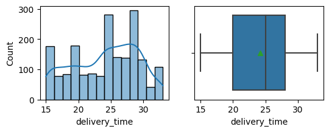

```python
#using a subplot with dimensions of 1 row 2 columns to keep graphs horizontally aligned.
fig, ax =plt.subplots(1,2,figsize=(6, 2))
sns.histplot(data=df,x = 'delivery_time', kde=True, ax=ax[0])
sns.boxplot(data=df,x = 'delivery_time',showmeans=True,ax=ax[1])
fig.show()
```

### Cuisine Type

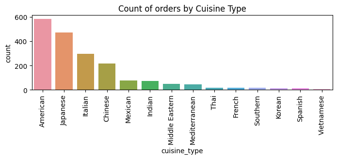

```python
#setting figure size
plt.figure(figsize=(8,2))
plt.title('Count of orders by Cuisine Type')
#ordering by value_counts
sns.countplot(data=df, x='cuisine_type',order = df['cuisine_type'].value_counts().index)
#rotated xticks for visibility
plt.xticks(rotation=90);
```

```python
#normalized value counts to show as cuisines as a percentage of orders placed.
cuisines = df['cuisine_type'].value_counts(normalize=True)
cuisines
```

```
American          0.307692
Japanese          0.247629
Italian           0.157007
Chinese           0.113277
Mexican           0.040569
Indian            0.038462
Middle Eastern    0.025817
Mediterranean     0.024236
Thai              0.010011
French            0.009484
Southern          0.008957
Korean            0.006849
Spanish           0.006322
Vietnamese        0.003688
Name: cuisine_type, dtype: float64
```

### Customers/Orders

```python
#used nunique to return the count of unique customer ID's
number_of_customers = df['customer_id'].nunique()

print(number_of_customers,'unique customers make up the 1800 orders.')
```

[output not shown]

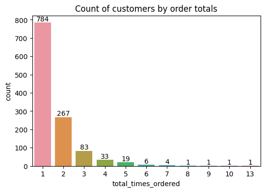

```python
#created a df of customer ID value counts
orders = pd.DataFrame(df['customer_id'].value_counts())
orders.reset_index(inplace = True)
#reset the index with inplace = True to rename columns for graphing purposes
orders.columns = ['customers','total_times_ordered']

plt.figure(figsize=(6,4))
plt.title('Count of customers by order totals')
ax = sns.countplot(data=orders, x='total_times_ordered')
# used ax.bar_label to display values of each bar on edge since the bars on the right of the graph are close to the axis.
# found this on stack exchange
ax.bar_label(ax.containers[0], label_type='edge')
plt.show()
```

Observations: Here we can see that 784 of the 1200 users only ordered through FoodHub once. The top customer placed 13 orders.

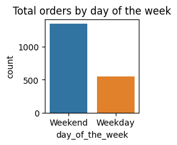

```python
#countplot of orders by day of the week
plt.figure(figsize=(2,2))
#resized and added title
plt.title('Total orders by day of the week')
sns.countplot(data=df, x='day_of_the_week');
```

Observations: More orders are placed on weekends.

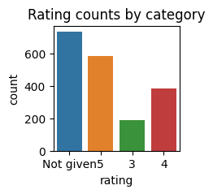

```python
#countplot of raing totals by category
plt.figure(figsize=(2,2))
plt.title('Rating counts by category')
sns.countplot(data=df, x='rating');
```

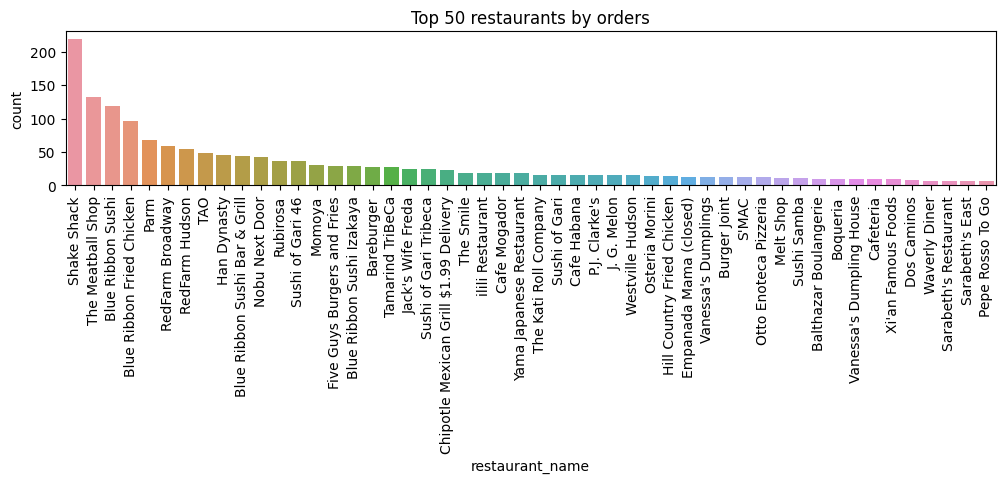

```python
# resizing and naming graph
plt.figure(figsize=(12,2))
plt.title('Top 50 restaurants by orders')
# used .value_counts().iloc[:50].index) to order the top 50 restauraunts by orders placed.
sns.countplot(x = 'restaurant_name', data = df, order = df['restaurant_name'].value_counts().iloc[:50].index)
#rotated ticks for visability
plt.xticks(rotation=90);
plt.show()
```

Observations: Here we can see the top 50 restaurants.

### **Question 7**: Which are the top 5 restaurants in terms of the number of orders received? [1 mark]

```python
#used .head() to return top 5
df['restaurant_name'].value_counts().head()
```

```
Shake Shack                  219
The Meatball Shop            132
Blue Ribbon Sushi            119
Blue Ribbon Fried Chicken     96
Parm                          68
Name: restaurant_name, dtype: int64
```

#### Observations:

##### The top 5 are:

###### 1 - Shake Shack (219)

###### 2 - The Meatball Shop (132)

###### 3 - Blue Ribbon Sushi (119)

###### 4 - Blue Ribbon Fried Chicken (96)

###### 5 - Parm (68)

### **Question 8**: Which is the most popular cuisine on weekends? [1 mark]

```python
#filtered day of the week to weekend and returned top cuisine type using value_counts().head(1)
top_weekend_cuisine = df[df['day_of_the_week'] == 'Weekend']['cuisine_type'].value_counts().head(1)
top_weekend_cuisine
```

```
American    415
Name: cuisine_type, dtype: int64
```

#### Observations: The most popular type of cuisine on weekends is American (415).

### **Question 9**: What percentage of the orders cost more than 20 dollars? [2 marks]

```python
#divided cost_of_orders over $20 by count of all cost_of_orders
over20 = (df['cost_of_the_order'][df['cost_of_the_order']>20].count()/df['cost_of_the_order'].count())

#formatted over20 to round to two decimals and have a % sign.
print(f"{over20:,.2%}")
```

```
29.24%
```

#### Observations: Here we can see that 29.24% of orders are more than $20

### **Question 10**: What is the mean order delivery time? [1 mark]

```python
#finding average of delivery_time column and rounding to two decimal places
avg_delivery = df['delivery_time'].mean().round(2)
print(avg_delivery, "mins")
```

```
24.16 mins
```

#### Observations: The average delivery time 24.16 minutes.

### **Question 11:** The company has decided to give 20% discount vouchers to the top 3 most frequent customers. Find the IDs of these customers and the number of orders they placed. [1 mark]

```python
#using head(3) to return top 3 value counts of customer_id in order to find 3 most buying customers.
top3 = df['customer_id'].value_counts().head(3)
print(top3)
```

```
52832    13
47440    10
83287     9
Name: customer_id, dtype: int64
```

#### Observations: Here we can see the top three customers are:

##### 52832 with 13 orders.

##### 47440 with 10 orders.

##### 83287 with 9 orders.

### **Question 12**: Perform a multivariate analysis to explore relationships between the important variables in the dataset. (It is a good idea to explore relations between numerical variables as well as relations between numerical and categorical variables) [10 marks]

### Ratings:

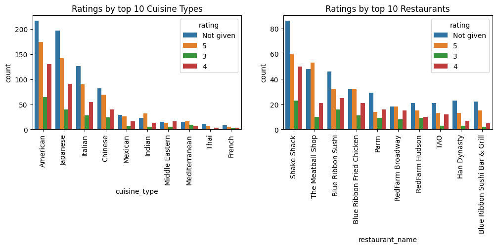

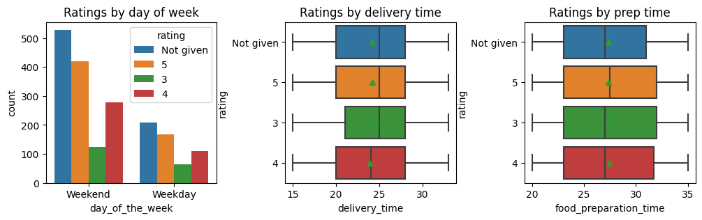

```python
#used subplots to keep graphs horizontally aligned
fig, ax =plt.subplots(1,2,figsize=(12, 3))
#created countplot of top ten cuisine types and set hue = ratings to see counts of each per cuisine type
sns.countplot(x = 'cuisine_type', data = df, order = df['cuisine_type'].value_counts().iloc[:10].index,hue = 'rating', ax=ax[0])
sns.countplot(x = 'restaurant_name', data = df, order = df['restaurant_name'].value_counts().iloc[:10].index,hue = 'rating',ax=ax[1])
ax[0].title.set_text('Ratings by top 10 Cuisine Types')
ax[1].title.set_text('Ratings by top 10 Restaurants')
#looping through each axis of the figure and rotating ticks 90 degrees
for ax in fig.axes:
    plt.sca(ax)
    plt.xticks(rotation=90)
fig.show()

fig, ax =plt.subplots(1,3,figsize=(12, 3))
sns.countplot(data=df,x='day_of_the_week',hue= 'rating', ax=ax[0])
sns.boxplot(data = df, x = 'delivery_time', y = 'rating',showmeans=True,ax=ax[1])
sns.boxplot(data = df, x = 'food_preparation_time', y = 'rating',showmeans=True,ax=ax[2])
#applying titles
ax[0].title.set_text('Ratings by day of week')
ax[1].title.set_text('Ratings by delivery time')
ax[2].title.set_text('Ratings by prep time')
#adjusting widthspace, otherwise 'Not given' was overlapping
fig.subplots_adjust(wspace=.4)
fig.show()
```

We can see in the boxplots that ratings seem largely unaffected by both food prep time and delivery time.

### Cuisine Type:

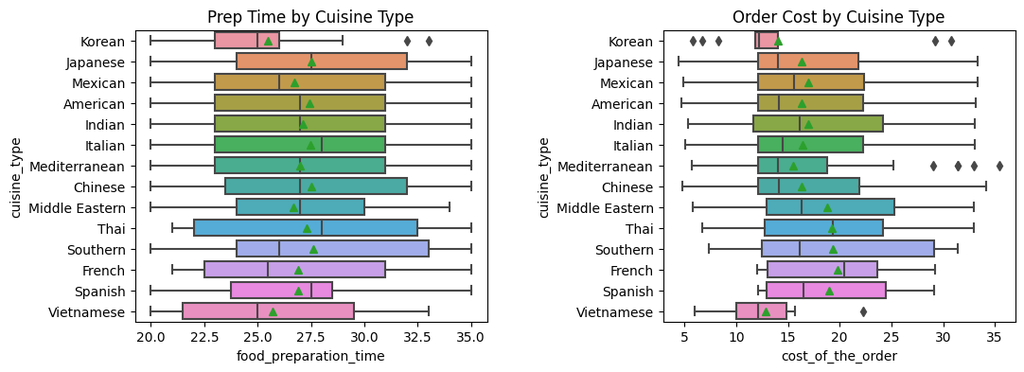

```python
fig, ax =plt.subplots(1,2,figsize=(12, 4))
sns.boxplot(data = df, x = 'food_preparation_time', y = 'cuisine_type',showmeans=True, ax=ax[0])
sns.boxplot(data = df, x = 'cost_of_the_order', y = 'cuisine_type',showmeans=True,ax=ax[1])
ax[0].title.set_text('Prep Time by Cuisine Type')
ax[1].title.set_text('Order Cost by Cuisine Type')
fig.subplots_adjust(wspace=.5)
fig.show()
```

Observations: From the boxplots we can see the variation of order cost and prep time between the cuisine types. There are several outliers in both. We can see Korean has outliers to the right of the right whisker in both, indicating that a large/expensive order may have taken longer to prepare.

### Day of the Week

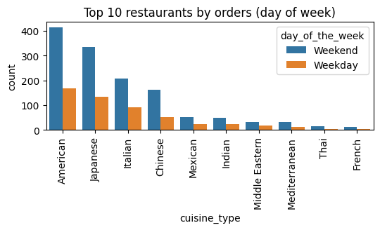

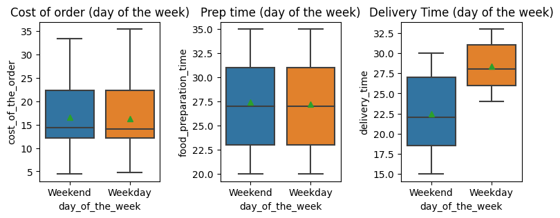

```python
plt.figure(figsize=(6,2))
plt.title('Top 10 restaurants by orders (day of week)')
#ordering/displaying top ten cuisines by value count, set hue = day_of_the_week to see totals categorized.
sns.countplot(x = 'cuisine_type', data = df, order = df['cuisine_type'].value_counts().iloc[:10].index,hue = 'day_of_the_week')
#rotated ticks for visibility
plt.xticks(rotation = 90)
plt.show()

#used sublots for better organization and resized graphs
fig, ax =plt.subplots(1,3,figsize=(9, 3))
sns.boxplot(data=df,x='day_of_the_week',y='cost_of_the_order',showmeans=True, ax=ax[0])
sns.boxplot(data=df,x='day_of_the_week',y='food_preparation_time',showmeans=True,ax=ax[1])
sns.boxplot(data=df,x='day_of_the_week',y='delivery_time',showmeans=True,ax=ax[2])
ax[0].title.set_text('Cost of order (day of the week)')
ax[1].title.set_text('Prep time (day of the week)')
ax[2].title.set_text('Delivery Time (day of the week)')
#expanded space between widths, otherwise overlapping
fig.subplots_adjust(wspace=.5)
fig.show()
```

Observations: We can see from the bar chart that weekends are busier for restaurants of all cuisine types, however we see higher avg. & median delivery times on weekdays. We see that prep time and cost of orders remain consistent.

### Correlation

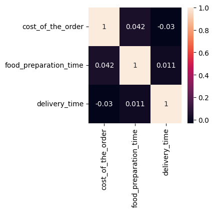

```python
#Creating list of numerical columns
num_vars = ['cost_of_the_order', 'food_preparation_time', 'delivery_time']
corr = df[num_vars].corr()

#set annot = true to see values in each square
plt.figure(figsize = (3,3))
sns.heatmap(corr, annot = True)
plt.show()
```

#### Observations: From the heatmap, we can see that there aren't very strong correlations between the variables. The strongest being prep time and cost of order.

### **Question 13:** The company wants to provide a promotional offer in the advertisement of the restaurants. The condition to get the offer is that the restaurants must have a rating count of more than 50 and the average rating should be greater than 4. Find the restaurants fulfilling the criteria to get the promotional offer. [3 marks]

```python
#filtering out 'not given' ratings and grouping by restaurant names with rating means over 4
over_4_stars = df[['restaurant_name','rating']][df['rating']!= 'Not given'].groupby('restaurant_name').mean()> 4
#filtering out 'not given' ratings and grouping by restaurant names with rating counts over 50
over_50_reviews = df[['restaurant_name','rating']][df['rating']!= 'Not given'].groupby('restaurant_name').count()> 50

#merging df's to find restaurants that match both criteria
promotion_restuaraunts = pd.merge(over_4_stars[over_4_stars['rating']== True], over_50_reviews[over_50_reviews['rating']== True],on ='restaurant_name')
promotion_restuaraunts
```

| restaurant_name | rating_x | rating_y |
| --- | --- | --- |
| Blue Ribbon Fried Chicken | True | True |
| Blue Ribbon Sushi | True | True |
| Shake Shack | True | True |
| The Meatball Shop | True | True |

### **Question 14:** The company charges the restaurant 25% on the orders having cost greater than 20 dollars and 15% on the orders having cost greater than 5 dollars. Find the net revenue generated by the company across all orders. [3 marks]

```python
#setting revenue = 0 then looping through each row in the cost_of_the_order column
rev = 0
for i in df['cost_of_the_order']:
    if (i > 20): #if the cost(i) is greater than 20, it multiplies the cost by .25 and adds the product to revenue.
        rev = rev + (i*0.25)
    elif (5 < i < 20):#if not it checks if the cost(i) is between 5 and 20 and will multiply cost by .15 and adds the product revenue
        rev = rev + (i*0.15)
    else:
        rev = rev + (i*0)#otherwise the cost gets multiplied by zero
print("${:.2f}".format(rev))
```

```
$6166.30
```

#### Observations: The net revenue is $6166.30

### **Question 15:** The company wants to analyze the total time required to deliver the food. What percentage of orders take more than 60 minutes to get delivered from the time the order is placed? (The food has to be prepared and then delivered.) [2 marks]

```python
#added 'total_time' column as the sum of prep and delivery time.
df['total_time'] = df['food_preparation_time']+df['delivery_time']
```

```python
# divided the count of orders with total wait times over 60 by count of all orders
over60 = (df['total_time'][df['total_time']> 60].count() / df['total_time'].count())
#formatted to 2 decimals
print("{:.2%}".format(over60))
```

```
10.54%
```

#### Observations: 10.54% of orders take more than 60 mins.

### **Question 16:** The company wants to analyze the delivery time of the orders on weekdays and weekends. How does the mean delivery time vary during weekdays and weekends? [2 marks]

```python
#used loc to filter to week/weekend and .mean() to find average delivery times
weekend = df.loc[df['day_of_the_week']=='Weekend','delivery_time'].mean()
weekday = df.loc[df['day_of_the_week']=='Weekday','delivery_time'].mean()

#formated to round to two decimal places
print("Weekdays:{:.2f} mins.".format(weekday))
print("Weekends:{:.2f} mins.".format(weekend))
#the difference of the delivery times
print("---diff. of {:.2f} mins.".format(weekday - weekend))
```

```
Weekdays:28.34 mins.
Weekends:22.47 mins.
---diff. of 5.87 mins.
```

### Recommendations:

- A customer incentive program that will reward reviews/consistent use of the app.
- Creating more in depth rating system with options besides 1-5, to acquire more data about why a certain review was given.
- A marketing campaign or promotion to inspire users to buy from the less popular restaurants/cuisine types.
- A subscription/discount for students or or a way to identify students from professionals in order to get better demographic data.
- A promotion or incentive to increase quantity of weekday purchases.
- Although delivery speed does not seem to affect ratings, decreasing weekday delivery time may be of interest.

```python
!jupyter nbconvert --to html /content/drive/MyDrive/Food
```

```
[NbConvertApp] Converting notebook /content/drive/MyDrive/Food to html
[NbConvertApp] Writing 1318171 bytes to /content/drive/MyDrive/Foo.html
```